# Data 605 Assignment 13

Anthony Pagan

April 29, 2019

HW13

# 1) Integration by substitution

Use integration by substitution to solve the integral below.

${\int{4e^{-7x}dx}}$ =

- u = ${e^{-7x}}$
- ${{4}\int e^{-7x}dx}$

# 2) Functions

Biologists are treating a pond contaminated with bacteria. The level of contamination is changing at a rate of ${\frac{dN}{dt}=\frac{3150}{t^4}-2}$ bacteria per cubic centimeter per day, where t is the number of days since treatment began. Find a function N( t ) to estimate the level of contamination if the level after 1 day was 6530 bacteria per cubic centimeter.

f(x)= ${{6530}{t^{1/4}}-2}$ =

- ${\int_1^tf(x)\frac{dN}{dt}}$

# 3) Area Functions

- f(x) = 2x -9
- Solve for y
- 2x - 9 = 0
- x = 4.5
- y = 2x -9
- A = 1/2(x*y)

```r
integrand <- function(x) {2*x-9}
A<-integrate(integrand, lower = 4, upper = 9)
A<-A[1]
```

**Total area is approx 20**

# 4) Graph Areas

Find the area of the region bounded by the graphs of the given equations. y = x2-2x-2, y = x + 2

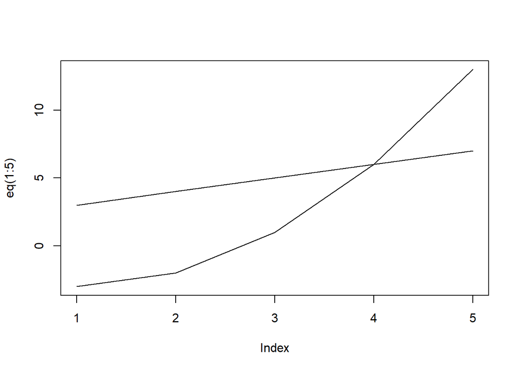

```r
eq <- function(x){x^2-2*x-2}
eq2<-function(x){x+2}
plot(eq(1:5), type='l')
lines(eq2(1:5), type='l')
```

```r
integrand <- function(x) {(x^2-2*x-2)-(x+2)}
A<-integrate(integrand, lower = 1, upper = 4)
A<-A[1]
```

**Area of region is approx -13.5**

# 5) Word Problems

A beauty supply store expects to sell 110 flat irons during the next year. It costs $3.75 to store one flat iron for one year.There is a fixed cost of $8.25 for each order. Find the lot size and the number of orders per year that will minimize inventory costs.

- Expected Unit Sales = 110
- Storage Costs = 3.75*(110-UnitsSold)
- Fixed Costs = -x*8.25

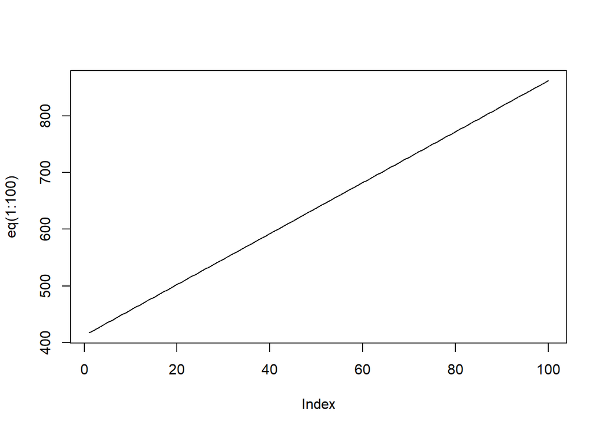

```r
x<-110
eq<- function(x){3.75*(110-x)+x*8.25}
plot(eq(1:100), type='l')
```

```r
integrand <- function(x) {3.75*(110-x)+x*8.25}
A<-integrate(integrand, lower = 0, upper = 1)
A<-as.double(A[1])
A<-A/100
```

**Selling 4.1475 lots of a 100 will minimize cost**

# 6) Integration II

Use integration by parts to solve the integral below. ${\int{ln(9x)}* x^6dx}$

- u = ln(9x) = ${\frac{9}{x}}$
- v = ${x^6dx}$ = ${5x^5}$
- = -ln(${\frac{9}{x}}$)-${5x^5}$+C

# 7) Density Function

Determine whether f ( x ) is a probability density function on the interval ${[1,e^6}]$ . If not, determine the value of the definite integral.

f(x) = ${\frac{1}{6x}}$ =

- ${\int_0^1\frac{-1}{6x^2}dx}$

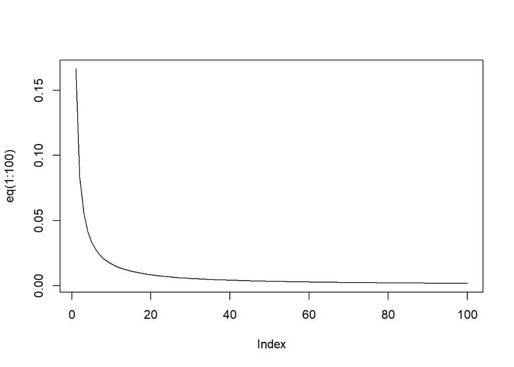

```r
eq<-function(x){1/(6*x)}
eq2<- function(x){exp(x)}
plot(eq(1:100), type='l')
```

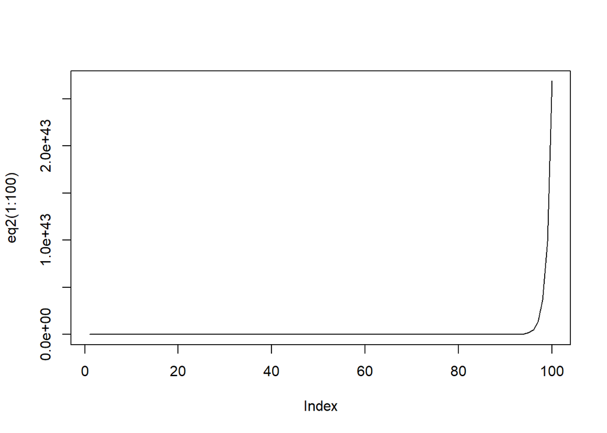

```r
plot(eq2(1:100),type='l')
```

```r
integrand <- function(x) {-1/(6*x^2)}
A<-integrate(integrand, lower = 1, upper = 10)
A<-A[1]
E<-integrand(1)
O<-integrand(exp(6))
```